# Toronto Rental Apartment Property Type Compairson

Lee Doucet

January 31st, 2021

Introduction

The City of Toronto protects renters in apartment buildings through a program called RentSafeTo where they enact a bylaw enforcement program, Apartment Building Standards (ABS). Specific maintenance standards and procedures are laid out for the tenant’s behalf, including their right to have a landlord respond to urgent service requests (e.g. no heat or water) within 24 hours of being reported. Tenants who experience problems with these standards are able to contact the RentSafeTo team through 311 to escalate their concerns. An important consideration is these protections apply to apartment buildings alone. Whose definition is that an “apartment building is a purpose-built rental building with 3 more storeys and 10 or more rental units but does not include long-term care, a licensed retirement home or a housing co-operative”(RentSafeTO, n.d.). This also excludes condo buildings, townhomes, and units residing within the basement level or main floor of a private home from the program.

With Toronto’s growing population and concerns over equitable access to housing, a one-size fits all approach with strictly private rentals would not address the housing concerns of all residents within Toronto. To ensure everyone has equal access to adequate housing, the Ontario Human Rights Commission (OHRC) promotes the increased availability of social housing in compliance with Canada’s commitment to provide adequate housing for all Canadians (Commission, n.d.). The largest social housing provider in Canada is the Toronto Community Housing Corporation (TCHC) and manages 60,000 rental housing units with a mandate to “to provide clean, safe, secure homes in a state of good repair to low and mode and moderate-income households, including seniors, families, singles, refugees, recent immigrants to Canada and people with special needs” (Corporation, n.d.).

The focus of this paper will be an exploratory analysis of the apartment buildings in Toronto, examining their state of condition and much progression Canada has made in regards to their policy goal of providing adequate housing for all Canadians. To answer that question, data will be pulled from the Toronto Open Data Portal exclusively. Once that has been investigated, any other research insights that present themselves will be examined that pertains to the Toronto rental market. The goal is provide a framework of data that can be built upon for policy planners at the city or advocacy organizations such as ACORN Toronto.Finally, as this research is exploratory, it will hope to highlights future areas of research opportunities and suggest new data avenues for the Toronto Open Data Portal to collect.

Data

Methodology

To investigate the rental apartment housing in Toronto, their open data portal was accessed from their website where a search was conducted for data sets related to apartments The query provided two results, Apartment Building Evaluation with a gold data quality score and Apartment Building Registration with a silver data quality score. Data sets are published by Municipal Licensing & Standards and covered under an Open Government License – Toronto, for distribution.

Data Description

Source

```
Both data sets include all apartment rental buildings in Toronto as per the
```

aforementioned definition in the introduction. Building owners are required to register and renew annually within the compliance of the RentSafeTO program. Audits are conducted by the city inspectors at least once every three years with increased frequency of inspections depending on the amount of property standard issues currently present in the building.The program has been in effect since 2017 when the first buildings were registered.

Data Sets

```
Apartment Building Evaluation Data Set Highlights (3462 Buildings Total)
```

- RSN: A 7-digit number to Identify the building across different data sets
- Property Type: Either Private, Social Housing, or TCHC
- Ward: Which of the 25 wards in Toronto does this building reside
- Score: Out of 100 what did this building score
- Confirmed Units: Total amount of units present in the building
- Year Built: When was this building built

  Apartment Building Registration Data Set Highlights (3461 Buildings Total)
- RSN: A 7-digit number to Identify the building across different data sets
- Property Type: Either Private, Social Housing, or TCHC
- PCODE: Postal Code of the building
- Property Management Company Name: Identify the owner of the building
- No Barrier Free Accessible Units: Number of accessible units present in the building

Key Features

The main benefit of using these two data sets is their interoperability with each other through the specific building identification number (RSN). This allows the combination of the regulation attributes (e.g. Fire Code) and the evaluation metrics (e.g. Building Score) to test if there are any correlations in the data. With the data conducted by inspectors there is strong reason to have confidence in the validity of what data has been collected. There is also the greater social good that comes from open data that informs citizens which buildings perform the best and which ones struggle with compliance. Having a clear metrics such as Building Score allows for other attributes to be tested against it to look for relationships, or the lack of them in the data. For example, we can examine the relationship between the property type of the building while analyzing it against the overall score of the building. The metric Score can also be further broken down into any quantifiable attributes presented (e.g. Security) that a part of the overall score if a narrower focus is desired for research.

Within the data there is a range of the completeness among the data fields. For instance, Amenities Available has most of its data displayed as NA. Some fields hold contradictory information with related fields with 2362 Islington Ave listing no pets, but in another field, says that small dogs are okay. Many fields require extensive cleaning for use, the Property Management Company field has many variations of spellings or additional punctuation that makes use difficult without proper cleaning of the data.

There are also data fields that are not present that would have been very helpful such as average rent or total number of validated violations reported against a building. All apartments that do not fall within the definition are also missing and add a significant amount to the rental inventory. It’s also not clear what fields account for what percentage of the total score if certain fields contain more weight or not. For instance, not all buildings have balconies, does that mean that the field is not calculated in total score for all buildings or just for buildings without a balcony.

From an ethical perspective, the primary concern is between whom the relationship is between in regards to the data. In each data set, it’s strictly how the building performs based on observable metrics but does not consider the lifeblood of the building, the residents. If a building gets a security score of 4 out of 5, for whom is that score based on, a male or a female, or even a visible minority? A woman walking from her car at night would have much different security needs to feel safe at night than a man. The The evaluation also only takes place within the building common areas so there is little indication of what is transpiring inside tenant space. The data does not say the tenants appliances are being taken care by the landlords and tenant. Landlords could possibly be incentivized to do the least amount of upkeep inside the tenant space to prevent the tenant from lodging a complaint. This could actually be happening and there would be no way to tell from this data. This is why it is important to use open data as a starting point to investigate and ask better questions that are informed with the data.

Merging the Data Sets

To make the data easier to work with, Apartment Evaluations was combined with Regulations by the mutual column RSN. With 100 columns together between the two data sets, 13 were selected based on their usefulness for a direct comparison (e.g. Score, Property Type, Postal Code) and other being attributes to investigate (e.g. Emergency Power, Fire Alarm status). Once they were organized together, the data was examined and areas for research analysis were investigated.

Research Question 1 – Do total scores differ among the three different rental building types?

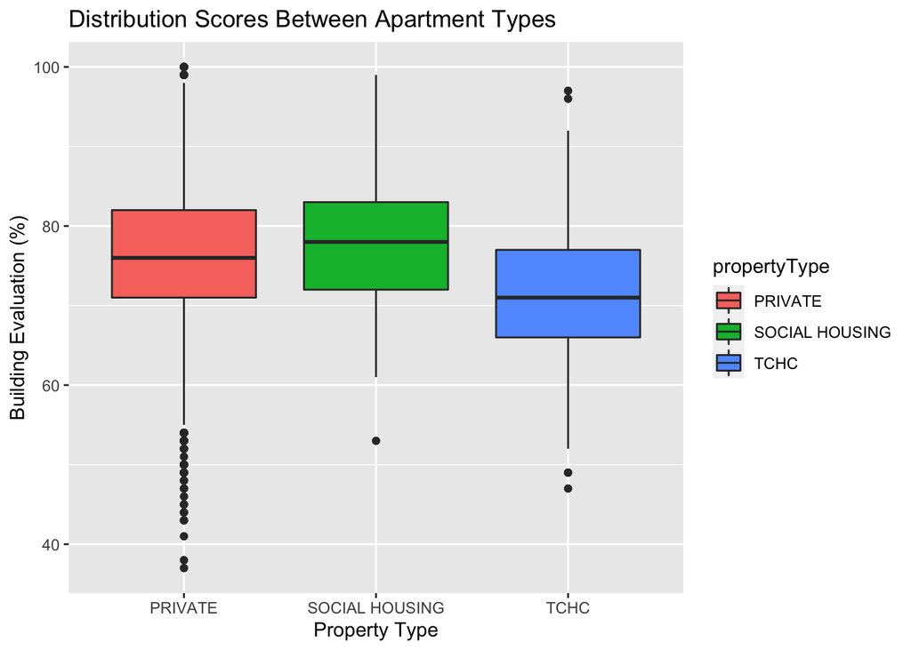

The results from Graph 1 show how the data is distributed among the three property types. Each box plot shows the range of the data where most of it located with the black line representing the median of the data. From this graph, social housing appears to have scored the highest with private rentals very close. TCHC housing is lagging behind the both of them with much lower scores. It also tells us the outliers from the data, demonstrating that private rental housing has the best overall units but also the worst. An abundance of lower units on the range for private rentals is not surprising considering some of the strategies enacted through the financialization of the private rental housing market. Take for example in the non-gentrifying parts of New York’s outer boroughs, the private equity firms that own them use strategic u nder maintenance for those who are low-income and immigrant populations. This group has little options to find better lodgings so they must suffer reduced services and higher rents(August and Walks 2018). Let’s examine the actual numbers of each property type present.

Summary statistics

| Property Type | Average Rental Score | Total Amount |
| --- | --- | --- |
| PRIVATE | 76.30 | 2881 |
| SOCIAL HOUSING | 77.67 | 238 |
| TCHC | 71.38 | 328 |

Table 1 makes it clearer that the social housing and TCHC are vastly under presented in the total amount of rental apartments in Toronto. This makes comparison more challenging to compare them both directly and accurately when there is such a discrepancy. This does provides a new direction with examining why there is such a difference in the total number of rental units built in the first place.

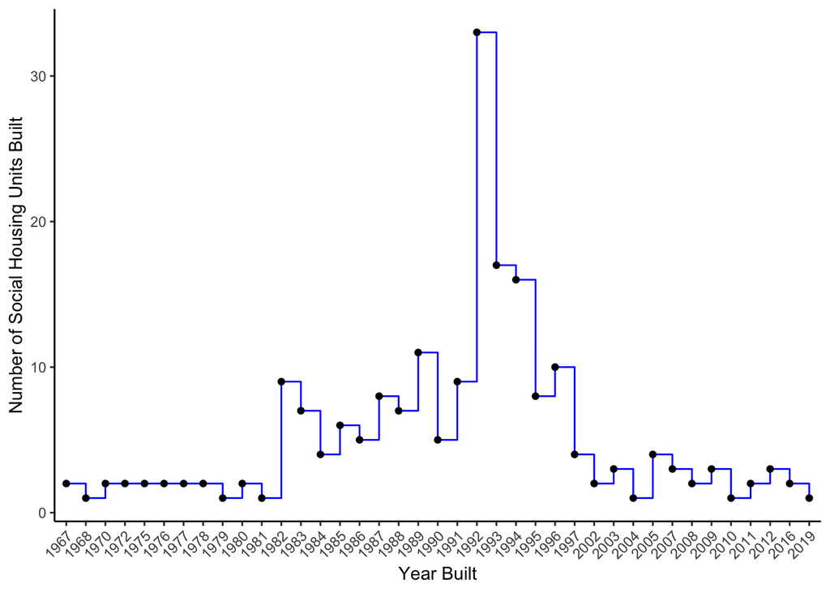

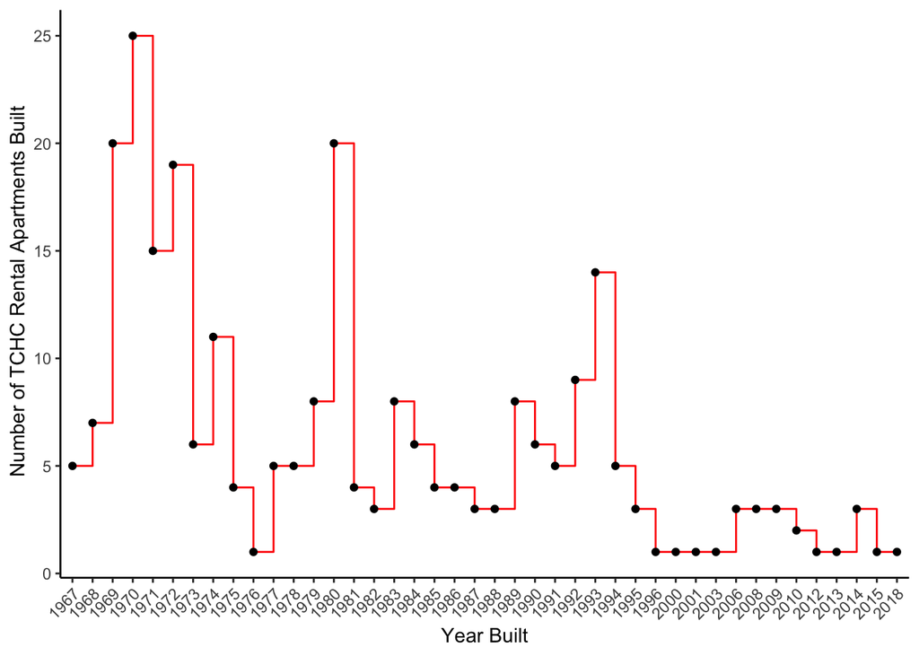

Looking at Graph 2, it shows the gradual decline of TCHC apartments being built since the 1960’s with a sharp drop off in the early 1990’s. With Social Housing, it shows lower builds per year with a sharp increase in the early 1990’s, followed by a steady drop off in supply. Both these line graphs are consistent with the Canadian government eliminating funding for new social housing in 1993 and downloading that responsibility to the provincial governments whom in 1995. After that a Conservative government was elected and they further downloaded these responsibilities to the municipal governments (August and Walks 2018). There has been little help from the private sector to fill this void in Toronto that has shifted their development away from rental housing apartments towards the more higher profits from condominium development (August and Walks 2018).

Research Question 2 – What about societies must vulnerable?

Conclusion

Toronto providing their open data is a boon for researchers looking for rental housing data and others curious about the current state of the market. An increase in access to this data can hopefully lead to better public policy or at the very minimum, better civic engagement in housing debates which access to is a international commitment by Canada. Within the context of the open data there is a connection between Toronto and the larger global phenomenon of governments not providing adequate numbers of social geared housing since the 1990’s. This is concerning as the private sector has little incentive to address this as they are focused on the higher profitability of condominiums in the city. Even more concerning is the state of the TCHC housing, as it scores lower than the private sector while being the refuge for Toronto’s most vulnerable. It is the belief of the author that governments must provide additional funding to bolster the supply of units and take more responsibility in the active care of these units. Considering it takes upwards of 2-3 years to build an apartment building when the first shovel hits the ground, the government must move forward on these actions immediately in hopes for a timely solution. It is the hope of this paper that further analysis can be conducted through the release of more open data and the work built upon by whomever has the desire and will.

References

August, Martine, and Alan Walks. 2018. “Gentrification, Suburban Decline, and the Financialization of Multi-Family Rental Housing: The Case of Toronto.” *Geoforum* 89: 124–36.

Commission, Ontario Human Rights. n.d. “VII - Social Housing.” http://www.ohrc.on.ca/en/policy-human-rights-and-rental-housing/vii-social-housing.

Corporation, Toronto Community Housing. n.d. “Toronto Community Housing.” https://www.toronto.ca/city-government/accountability-operations-customer-service/city-administration/city-managers-office/agencies-corporations/corporations/toronto-community-housing/.

RentSafeTO. n.d. “RentSafeTO for Tenants.” https://www.toronto.ca/community-people/housing-shelter/rental-housing-tenant-information/rental-housing-standards/apartment-building-standards/rentsafeto-for-tenants/.

Tomlin, Bryan. 2017. “Examining Differential Treatment of Single Mothers and People with Disabilities in the Apartment Rental Market.” *Economics Letters* 161: 34–37.

Wickham, Hadley. 2016. *Ggplot2: Elegant Graphics for Data Analysis*. Springer-Verlag New York. https://ggplot2.tidyverse.org.